# Import Libraries

### Electronics and Semicon

```python
df['ElectronicsAndSemicon'].describe()
```

```
count    3998.000000
mean       95.328414
std       158.241218
min        -1.000000
25%        -1.000000
50%        -1.000000
75%       233.000000
max       612.000000
Name: ElectronicsAndSemicon, dtype: float64
```

```python
(df['ElectronicsAndSemicon'][df['ElectronicsAndSemicon']!=-1].count()/len(df))*100
```

```
28.61430715357679
```

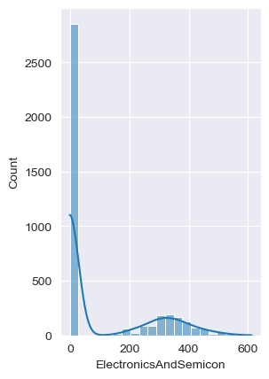

```python
plt.subplot(121)
sns.histplot(x=df['ElectronicsAndSemicon'],kde=True)
```

#### Observation

- 28.6% of candidates gave ElectronicsAndSemicon exam

### Computer Science

```python
df['ComputerScience'].describe()
```

```
count    3998.000000
mean       90.742371
std       175.273083
min        -1.000000
25%        -1.000000
50%        -1.000000
75%        -1.000000
max       715.000000
Name: ComputerScience, dtype: float64
```

```python
(df['ComputerScience'][df['ComputerScience']!=-1].count()/len(df))*100
```

```
22.56128064032016
```

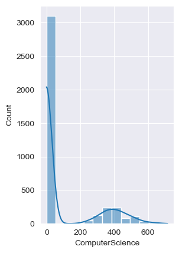

```python
plt.subplot(121)
sns.histplot(x=df['ComputerScience'],kde=True)
```

#### Observations

- 22.561% of candidates have attempted the Computer Science exam

### Mechanical Engineering

```python
df['MechanicalEngg'].describe()
```

```
count    3998.000000
mean       22.974737
std        98.123311
min        -1.000000
25%        -1.000000
50%        -1.000000
75%        -1.000000
max       623.000000
Name: MechanicalEngg, dtype: float64
```

```python
(df['MechanicalEngg'][df['MechanicalEngg']!=-1].count()/len(df))*100
```

```
5.877938969484743
```

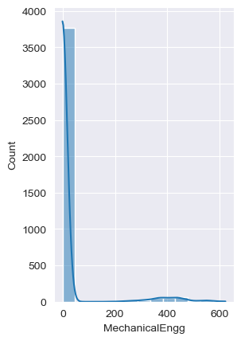

```python
plt.subplot(121)
sns.histplot(x=df['MechanicalEngg'],kde=True)
```

#### Observations

- 5.9 % candidates have attempted Mechanical Enggineering section

### Electrical Engineering

```python
df['ElectricalEngg'].describe()
```

```
count    3998.000000
mean       16.478739
std        87.585634
min        -1.000000
25%        -1.000000
50%        -1.000000
75%        -1.000000
max       676.000000
Name: ElectricalEngg, dtype: float64
```

```python
(df['ElectricalEngg'][df['ElectricalEngg']!=-1].count()/len(df))*100
```

```
4.027013506753377
```

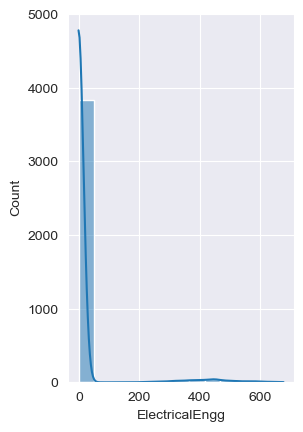

```python
plt.subplot(121)
sns.histplot(x=df['ElectricalEngg'],kde=True)
```

#### Observation

- Only 4% of candidates attempted Elctrical Engineering

### Telecom Engg

```python
df['TelecomEngg'].describe()
```

```
count    3998.000000
mean       31.851176
std       104.852845
min        -1.000000
25%        -1.000000
50%        -1.000000
75%        -1.000000
max       548.000000
Name: TelecomEngg, dtype: float64
```

```python
(df['TelecomEngg'][df['TelecomEngg']!=-1].count()/len(df))*100
```

```
9.354677338669335
```

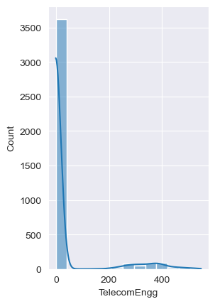

```python
plt.subplot(121)
sns.histplot(x=df['TelecomEngg'],kde=True)
```

#### Observation

- Only 9% candidates attempted telecom engg

### Civil Engg

```python
df['CivilEngg'].describe()
```

```
count    3998.000000
mean        2.683842
std        36.658505
min        -1.000000
25%        -1.000000
50%        -1.000000
75%        -1.000000
max       516.000000
Name: CivilEngg, dtype: float64
```

```python
(df['CivilEngg'][df['CivilEngg']!=-1].count()/len(df))*100
```

```
1.0505252626313157
```

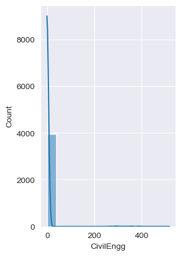

```python
plt.subplot(121)
sns.histplot(x=df['CivilEngg'],kde=True)
```

#### Observation

- Only 1% of candidates attempted the CivilEngg

### Personality Tests

```python
df['conscientiousness'].describe()
```

```
count    3998.000000
mean       -0.037831
std         1.028666
min        -4.126700
25%        -0.713525
50%         0.046400
75%         0.702700
max         1.995300
Name: conscientiousness, dtype: float64
```

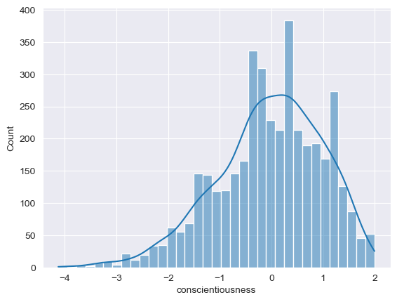

```python
sns.histplot(x=df['conscientiousness'],kde=True)
```

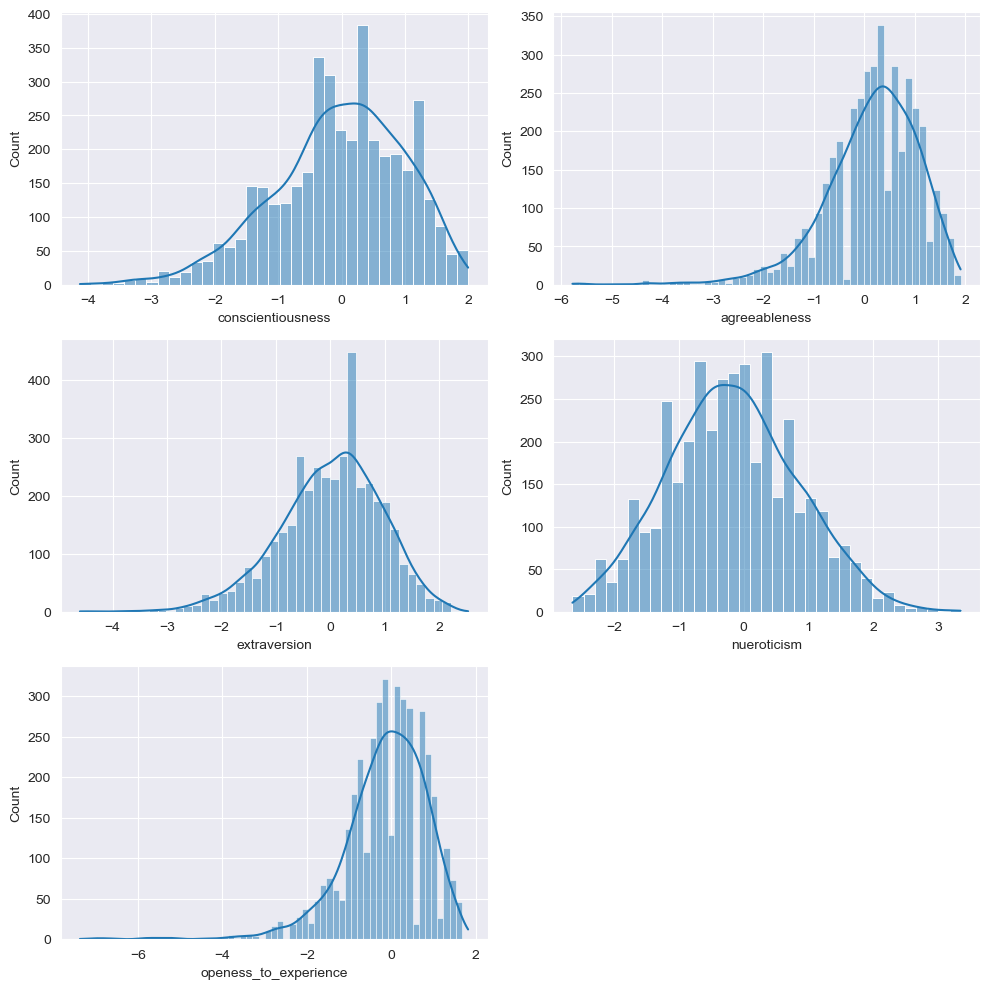

```python
personality_test_scores=df.iloc[:,33:]
count=1
plt.figure(figsize=(10,10))
for col in (personality_test_scores.columns):

    plt.subplot(3,2,count)
    sns.histplot(x=df[col],kde=True)
    count+=1
plt.tight_layout()
```

#### Observation

- Except nueroticism, other personality traits are left skewed

# Handling outliers

```python
def remove_outliers_iqr(df,column_name):
    # Calculate Q1 (25th percentile) and Q3 (75th percentile)
    Q1 = df[column_name].quantile(0.25)
    Q3 = df[column_name].quantile(0.75)
    # Calculate IQR (Interquartile Range)
    IQR = Q3 - Q1

    # Define the lower and upper bounds for outlier detection
    lower_bound = Q1 -1.5 * IQR
    upper_bound = Q3 +1.5* IQR

    def checkoutlier(x):
        if x<lower_bound or x>upper_bound:
            return None
        return x
    # Replace outliers with None
    return df[column_name].apply(checkoutlier)
```

```python
remove_outliers_iqr(df,'Salary')
```

```
0       4.20
1       5.00
2       3.25
3        NaN
4       2.00
        ...
3993    2.80
3994    1.00
3995    3.20
3996    2.00
3997    4.00
Name: Salary, Length: 3998, dtype: float64
```

```python
numerical_cols=[col for col in df.columns if df[col].dtype!='O'][1:]
categorical_cols=[col for col in df.columns if df[col].dtype=='O'][1:]
clean_df=df[numerical_cols]
clean_df
```

|  | Salary | DOJ | DOL | DOB | 10percentage | 12graduation | 12percentage | CollegeID | CollegeGPA | CollegeCityID | ... | ComputerScience | MechanicalEngg | ElectricalEngg | TelecomEngg | CivilEngg | conscientiousness | agreeableness | extraversion | nueroticism | openess_to_experience |
| --- | --- | --- | --- | --- | --- | --- | --- | --- | --- | --- | --- | --- | --- | --- | --- | --- | --- | --- | --- | --- | --- |
| 0 | 4.20 | 2012-06-01 | 2050-12-31 | 1990-02-19 | 84.30 | 2007 | 95.80 | 1141 | 7.800 | 1141 | ... | -1 | -1 | -1 | -1 | -1 | 0.9737 | 0.8128 | 0.5269 | 1.35490 | -0.4455 |
| 1 | 5.00 | 2013-09-01 | 2050-12-31 | 1989-10-04 | 85.40 | 2007 | 85.00 | 5807 | 7.006 | 5807 | ... | -1 | -1 | -1 | -1 | -1 | -0.7335 | 0.3789 | 1.2396 | -0.10760 | 0.8637 |
| 2 | 3.25 | 2014-06-01 | 2050-12-31 | 1992-08-03 | 85.00 | 2010 | 68.20 | 64 | 7.000 | 64 | ... | -1 | -1 | -1 | -1 | -1 | 0.2718 | 1.7109 | 0.1637 | -0.86820 | 0.6721 |
| 3 | 11.00 | 2011-07-01 | 2050-12-31 | 1989-12-05 | 85.60 | 2007 | 83.60 | 6920 | 7.464 | 6920 | ... | -1 | -1 | -1 | -1 | -1 | 0.0464 | 0.3448 | -0.3440 | -0.40780 | -0.9194 |
| 4 | 2.00 | 2014-03-01 | 2015-03-01 | 1991-02-27 | 78.00 | 2008 | 76.80 | 11368 | 7.390 | 11368 | ... | -1 | -1 | -1 | -1 | -1 | -0.8810 | -0.2793 | -1.0697 | 0.09163 | -0.1295 |
| ... | ... | ... | ... | ... | ... | ... | ... | ... | ... | ... | ... | ... | ... | ... | ... | ... | ... | ... | ... | ... | ... |
| 3993 | 2.80 | 2011-10-01 | 2012-10-01 | 1987-04-15 | 52.09 | 2006 | 55.50 | 6268 | 6.150 | 6268 | ... | -1 | -1 | -1 | -1 | -1 | -0.1082 | 0.3448 | 0.2366 | 0.64980 | -0.9194 |
| 3994 | 1.00 | 2013-07-01 | 2013-07-01 | 1992-08-27 | 90.00 | 2009 | 93.00 | 4883 | 7.730 | 4883 | ... | -1 | -1 | -1 | -1 | -1 | -0.3027 | 0.8784 | 0.9322 | 0.77980 | -0.0943 |
| 3995 | 3.20 | 2013-07-01 | 2050-12-31 | 1991-07-03 | 81.86 | 2008 | 65.50 | 9786 | 7.000 | 9786 | ... | -1 | -1 | -1 | -1 | -1 | -1.5765 | -1.5273 | -1.5051 | -1.31840 | -0.7615 |
| 3996 | 2.00 | 2014-07-01 | 2015-01-01 | 1992-03-20 | 78.72 | 2010 | 69.88 | 979 | 7.042 | 979 | ... | 438 | -1 | -1 | -1 | -1 | -0.1590 | 0.0459 | -0.4511 | -0.36120 | -0.0943 |
| 3997 | 4.00 | 2013-02-01 | 2050-12-31 | 1991-02-26 | 70.60 | 2008 | 68.00 | 6609 | 6.800 | 6609 | ... | -1 | -1 | -1 | -1 | -1 | -1.1128 | -0.2793 | -0.6343 | 1.32553 | -0.6035 |

3998 rows × 27 columns

```python
for col in numerical_cols:
    clean_df.loc[:,col]=remove_outliers_iqr(df,col)
clean_df
```

|  | Salary | DOJ | DOL | DOB | 10percentage | 12graduation | 12percentage | CollegeID | CollegeGPA | CollegeCityID | ... | ComputerScience | MechanicalEngg | ElectricalEngg | TelecomEngg | CivilEngg | conscientiousness | agreeableness | extraversion | nueroticism | openess_to_experience |
| --- | --- | --- | --- | --- | --- | --- | --- | --- | --- | --- | --- | --- | --- | --- | --- | --- | --- | --- | --- | --- | --- |
| 0 | 4.20 | 2012-06-01 | 2050-12-31 | 1990-02-19 | 84.30 | 2007.0 | 95.80 | 1141 | 7.800 | 1141 | ... | -1.0 | -1.0 | -1.0 | -1.0 | -1.0 | 0.9737 | 0.8128 | 0.5269 | 1.35490 | -0.4455 |
| 1 | 5.00 | 2013-09-01 | 2050-12-31 | 1989-10-04 | 85.40 | 2007.0 | 85.00 | 5807 | 7.006 | 5807 | ... | -1.0 | -1.0 | -1.0 | -1.0 | -1.0 | -0.7335 | 0.3789 | 1.2396 | -0.10760 | 0.8637 |
| 2 | 3.25 | 2014-06-01 | 2050-12-31 | 1992-08-03 | 85.00 | 2010.0 | 68.20 | 64 | 7.000 | 64 | ... | -1.0 | -1.0 | -1.0 | -1.0 | -1.0 | 0.2718 | 1.7109 | 0.1637 | -0.86820 | 0.6721 |
| 3 | NaN | 2011-07-01 | 2050-12-31 | 1989-12-05 | 85.60 | 2007.0 | 83.60 | 6920 | 7.464 | 6920 | ... | -1.0 | -1.0 | -1.0 | -1.0 | -1.0 | 0.0464 | 0.3448 | -0.3440 | -0.40780 | -0.9194 |
| 4 | 2.00 | 2014-03-01 | 2015-03-01 | 1991-02-27 | 78.00 | 2008.0 | 76.80 | 11368 | 7.390 | 11368 | ... | -1.0 | -1.0 | -1.0 | -1.0 | -1.0 | -0.8810 | -0.2793 | -1.0697 | 0.09163 | -0.1295 |
| ... | ... | ... | ... | ... | ... | ... | ... | ... | ... | ... | ... | ... | ... | ... | ... | ... | ... | ... | ... | ... | ... |
| 3993 | 2.80 | 2011-10-01 | 2012-10-01 | 1987-04-15 | 52.09 | 2006.0 | 55.50 | 6268 | 6.150 | 6268 | ... | -1.0 | -1.0 | -1.0 | -1.0 | -1.0 | -0.1082 | 0.3448 | 0.2366 | 0.64980 | -0.9194 |
| 3994 | 1.00 | 2013-07-01 | 2013-07-01 | 1992-08-27 | 90.00 | 2009.0 | 93.00 | 4883 | 7.730 | 4883 | ... | -1.0 | -1.0 | -1.0 | -1.0 | -1.0 | -0.3027 | 0.8784 | 0.9322 | 0.77980 | -0.0943 |
| 3995 | 3.20 | 2013-07-01 | 2050-12-31 | 1991-07-03 | 81.86 | 2008.0 | 65.50 | 9786 | 7.000 | 9786 | ... | -1.0 | -1.0 | -1.0 | -1.0 | -1.0 | -1.5765 | -1.5273 | -1.5051 | -1.31840 | -0.7615 |
| 3996 | 2.00 | 2014-07-01 | 2015-01-01 | 1992-03-20 | 78.72 | 2010.0 | 69.88 | 979 | 7.042 | 979 | ... | NaN | -1.0 | -1.0 | -1.0 | -1.0 | -0.1590 | 0.0459 | -0.4511 | -0.36120 | -0.0943 |
| 3997 | 4.00 | 2013-02-01 | 2050-12-31 | 1991-02-26 | 70.60 | 2008.0 | 68.00 | 6609 | 6.800 | 6609 | ... | -1.0 | -1.0 | -1.0 | -1.0 | -1.0 | -1.1128 | -0.2793 | -0.6343 | 1.32553 | -0.6035 |

3998 rows × 27 columns

```python
clean_df=pd.concat([clean_df,df[categorical_cols]],axis=1)
```

```python
clean_df.isnull().sum()
```

```
Salary                   109
DOJ                       19
DOL                        0
DOB                       68
10percentage              30
12graduation              45
12percentage               1
CollegeID                  0
CollegeGPA                27
CollegeCityID              0
GraduationYear             2
English                   15
Logical                   18
Quant                     25
Domain                   246
ComputerProgramming        2
ElectronicsAndSemicon      2
ComputerScience          902
MechanicalEngg           235
ElectricalEngg           161
TelecomEngg              374
CivilEngg                 42
conscientiousness         39
agreeableness            123
extraversion              40
nueroticism               15
openess_to_experience     95
JobCity                  461
Gender                     0
10board                    0
12board                    0
CollegeTier                0
Degree                     0
Specialization             0
CollegeCityTier            0
CollegeState               0
dtype: int64
```

```python
clean_df.dropna(axis=0,inplace=True)
```

```python
clean_df.isna().sum()
```

```
Salary                   0
DOJ                      0
DOL                      0
DOB                      0
10percentage             0
12graduation             0
12percentage             0
CollegeID                0
CollegeGPA               0
CollegeCityID            0
GraduationYear           0
English                  0
Logical                  0
Quant                    0
Domain                   0
ComputerProgramming      0
ElectronicsAndSemicon    0
ComputerScience          0
MechanicalEngg           0
ElectricalEngg           0
TelecomEngg              0
CivilEngg                0
conscientiousness        0
agreeableness            0
extraversion             0
nueroticism              0
openess_to_experience    0
JobCity                  0
Gender                   0
10board                  0
12board                  0
CollegeTier              0
Degree                   0
Specialization           0
CollegeCityTier          0
CollegeState             0
dtype: int64
```

# Bivariate Analysis

### Q Salary range of candidates who didn't mentioned their job City

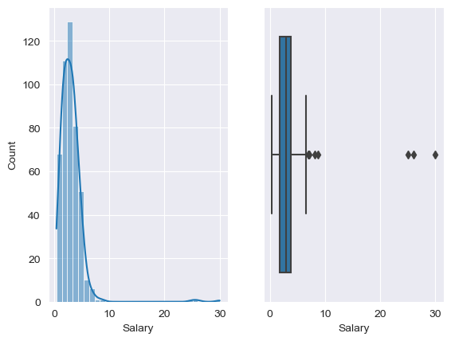

```python
plt.figure9figsize=(10,10)
plt.subplot(121)
sns.histplot(df['Salary'][df['JobCity'].isna()],kde=True,bins=30)
plt.subplot(122)
sns.boxplot(x=df['Salary'][df['JobCity'].isna()])
```

#### Observaton

- Most candidates belong to salary range <10L

### Candidates who didn't mentioned Job City and who didn't mentioned they DOL

```python
df[(df['JobCity'].isna())&(df['JobCity']=='2050-12-31')]
```

|  | ID | Salary | DOJ | DOL | Designation | JobCity | Gender | DOB | 10percentage | 10board | ... | ComputerScience | MechanicalEngg | ElectricalEngg | TelecomEngg | CivilEngg | conscientiousness | agreeableness | extraversion | nueroticism | openess_to_experience |
| --- | --- | --- | --- | --- | --- | --- | --- | --- | --- | --- | --- | --- | --- | --- | --- | --- | --- | --- | --- | --- | --- |

0 rows × 38 columns

### Highest package count in different JobCities

```python
salary_gret_10_percity=df[['JobCity','Salary']][(df['Salary']>10)].value_counts(subset=['JobCity'])
salary_gret_10_percity
```

```
JobCity
bangalore         10
gurgaon            3
mumbai             3
dubai              2
hyderabad          2
noida              2
pune               2
angul              1
bhopal             1
greater noida      1
johannesburg       1
kalmar, sweden     1
london             1
maharajganj        1
new delhi          1
panchkula          1
Name: count, dtype: int64
```

[output not shown]

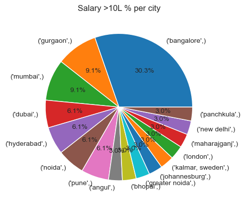

```python
plt.title('Salary >10L % per city')
plt.pie(x=salary_gret_10_percity.to_list(),labels=salary_gret_10_percity.index,autopct='%1.1f%%')
```

#### Observation

- 30.3% of salary packages greater than 10LPA were given in banglore based companies

### Relation between Salary and 10, 12 th, GPA of the candidates

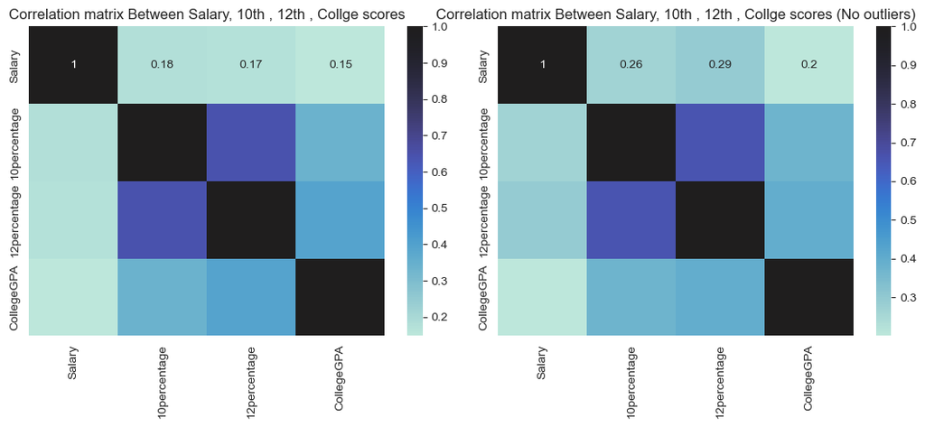

```python
plt.figure(figsize=(11,5))
plt.subplot(121)
plt.title('Correlation matrix Between Salary, 10th , 12th , Collge scores')
sns.heatmap(df[['Salary','10percentage','12percentage','CollegeGPA']].corr(),annot=True,center=1)
plt.subplot(122)
plt.title('Correlation matrix Between Salary, 10th , 12th , Collge scores (No outliers)')
sns.heatmap(clean_df[['Salary','10percentage','12percentage','CollegeGPA']].corr(),annot=True,center=1)
plt.tight_layout()
```

#### Observation

- There is no significant relationship between salary and other scores

### Relation between Salary>10Lakhs and the score(10,12, college)

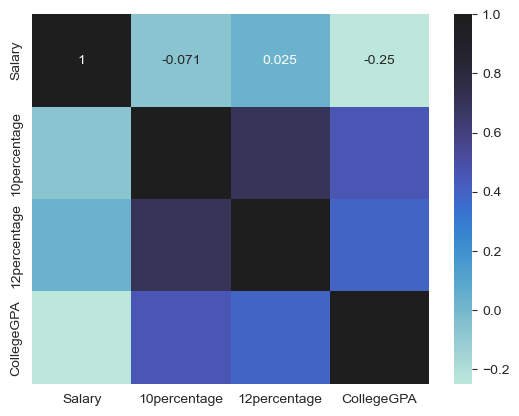

```python
sns.heatmap(df[df['Salary']>10][['Salary','10percentage','12percentage','CollegeGPA']].corr(),annot=True,center=1)
```

#### Observation

- There is no significant relationship between candidates with salary >10 lakhs and their 10,12,college scores

### Salary vs 10th, 12th board, Collge Tier

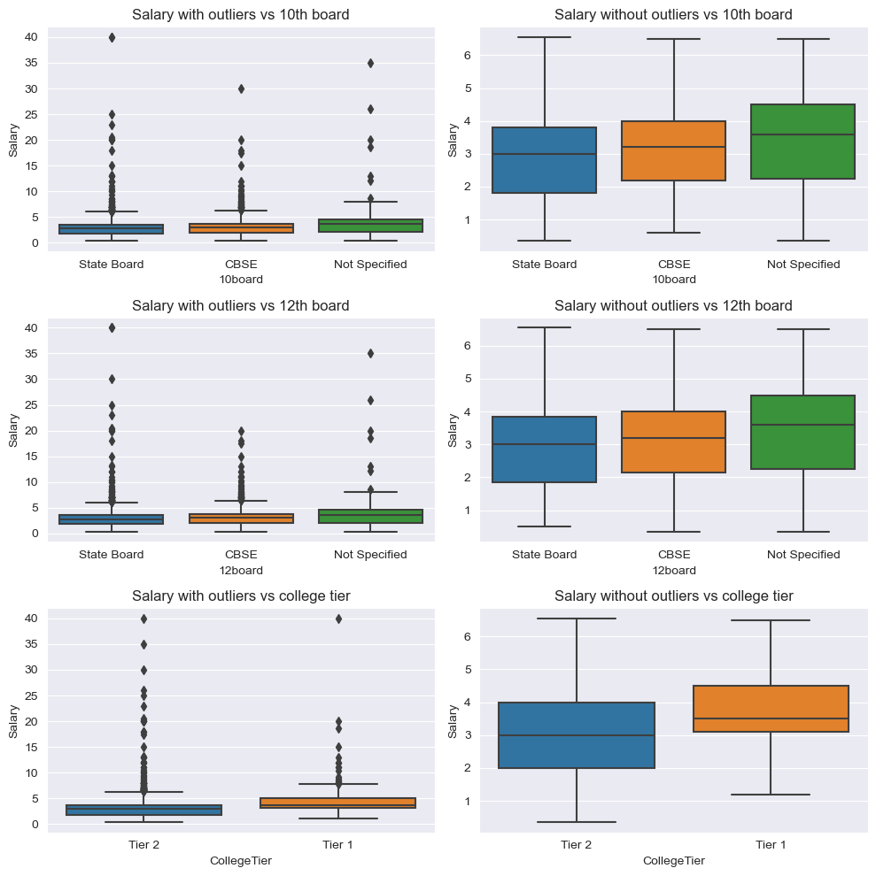

```python
plt.figure(figsize=(10,10))
plt.subplot(321)
plt.title('Salary with outliers vs 10th board')
sns.boxplot(data=df[['Salary','10board']],x='10board',y='Salary')
plt.subplot(322)
plt.title('Salary without outliers vs 10th board')
sns.boxplot(data=clean_df[['Salary','10board']],x='10board',y='Salary')
plt.subplot(323)
plt.title('Salary with outliers vs 12th board')
sns.boxplot(data=df[['Salary','12board']],x='12board',y='Salary')
plt.subplot(324)
plt.title('Salary without outliers vs 12th board')
sns.boxplot(data=clean_df[['Salary','12board']],x='12board',y='Salary')
plt.subplot(325)
plt.title('Salary with outliers vs college tier')
sns.boxplot(data=df[['Salary','CollegeTier']],x='CollegeTier',y='Salary')
plt.subplot(326)
plt.title('Salary without outliers vs college tier')
sns.boxplot(data=clean_df[['Salary','CollegeTier']],x='CollegeTier',y='Salary')
plt.tight_layout()
```

#### Observation

- Candidates who studied in CBSE board and also in Tier 1 college tend to get a better median salary

### Degree and Specialization vs Salary

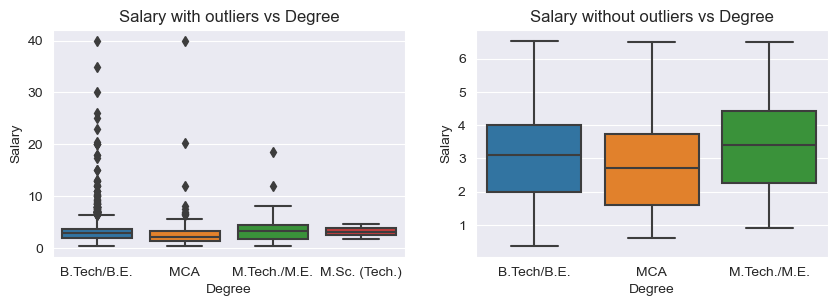

```python
plt.figure(figsize=(10,10))
plt.subplot(321)
plt.title('Salary with outliers vs Degree')
sns.boxplot(data=df[['Salary','Degree']],x='Degree',y='Salary')
plt.subplot(322)
plt.title('Salary without outliers vs Degree')
sns.boxplot(data=clean_df[['Salary','Degree']],x='Degree',y='Salary')
```

#### Observations

- The density of outliers is more in B.Tech/BE degree than M.Tech/ME. Hence, higher packages are more likely be secured by studying B.Tech.
- But when outliers are removed, M.Tech offers better median package than even MCA.

```python
salary_special=df[['Salary','Specialization']].groupby(by='Specialization')
```

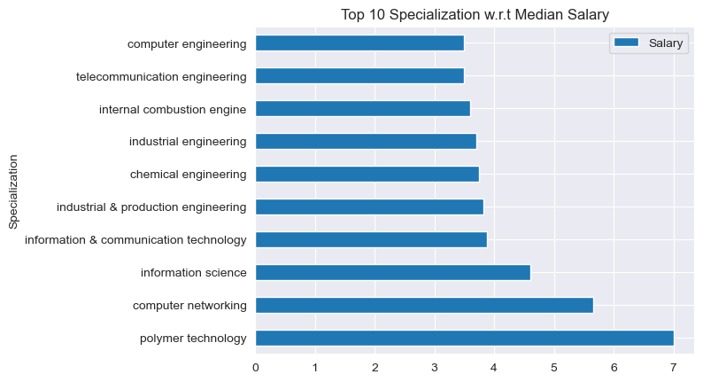

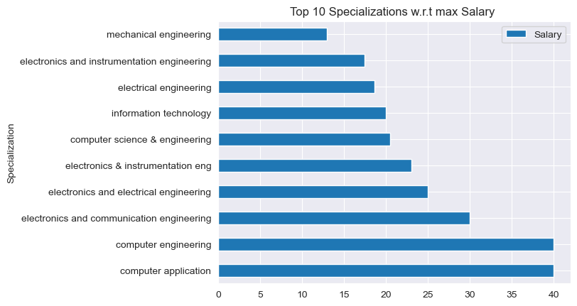

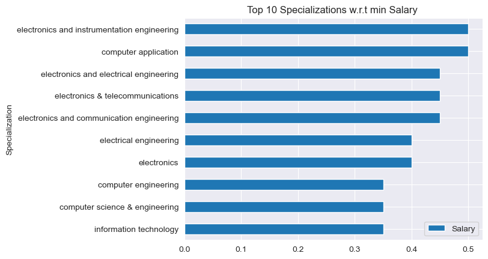

```python
plt.figure(figsize=(10,10))
salary_special.median().sort_values(by='Salary',ascending=False)[:10].plot(kind='barh')
plt.title('Top 10 Specialization w.r.t Median Salary')
salary_special.max().sort_values(by='Salary',ascending=False)[:10].plot(kind='barh')
plt.title('Top 10 Specializations w.r.t max Salary ')
salary_special.min().sort_values(by='Salary')[:10].plot(kind='barh')
plt.title('Top 10 Specializations w.r.t min Salary ')
```

#### Observation

- Max Median salary is offered by Polymer Technology Specialization
- Max Salary is offered by Computer Application Specialization
- Min Salary is offered by Information Technology Specialization

### Gender vs Salary

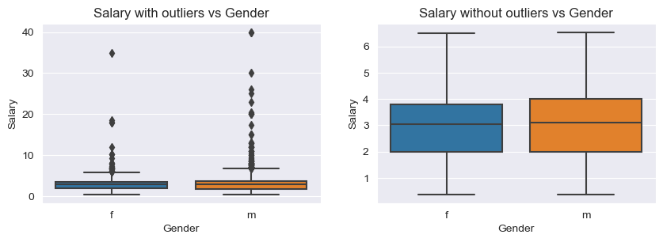

```python
plt.figure(figsize=(10,10))
plt.subplot(321)
plt.title('Salary with outliers vs Gender')
sns.boxplot(data=df[['Salary','Gender']],x='Gender',y='Salary')
plt.subplot(322)
plt.title('Salary without outliers vs Gender')
sns.boxplot(data=clean_df[['Salary','Gender']],x='Gender',y='Salary')
```

#### Observation

- Median compensation between male and female candidates is simiilar.
- But the density of outliers is much more in male candidates than female candidates

### Relationship between College State and Salary

```python
salary_collegestate=df[['Salary','CollegeState']].groupby(by='CollegeState')
```

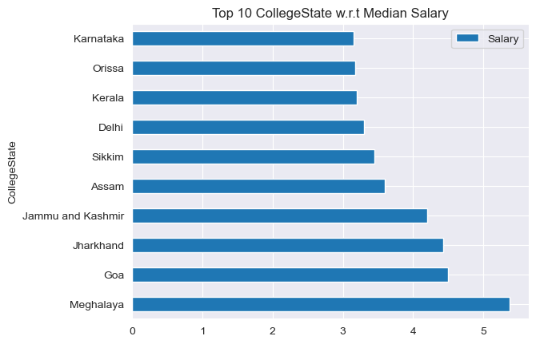

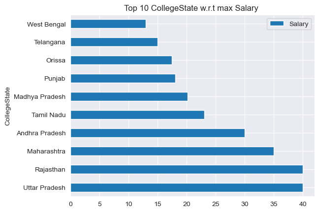

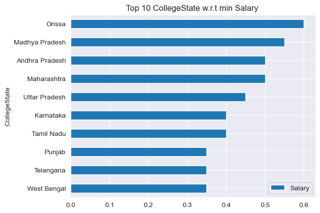

```python
plt.figure(figsize=(10,10))
salary_collegestate.median().sort_values(by='Salary',ascending=False)[:10].plot(kind='barh')
plt.title('Top 10 CollegeState w.r.t Median Salary')
salary_collegestate.max().sort_values(by='Salary',ascending=False)[:10].plot(kind='barh')
plt.title('Top 10 CollegeState w.r.t max Salary ')
salary_collegestate.min().sort_values(by='Salary')[:10].plot(kind='barh')
plt.title('Top 10 CollegeState w.r.t min Salary ')
```

### Observation

- Max Median packages offered to candidates studied at Meghalaya
- Maximum package were offered to candidates who studied in a UP college
- Minimum package was offered to candidate who studied in a WB college

### Maximum Salary secured by a candidate who didn't gave any Computer related domain during AMCAT

```python
df[(df['ComputerProgramming']==-1) & (df['ComputerScience']==-1)]['Salary'].sort_values(ascending=False)
```

```
166     18.60
2493    17.45
2152    12.00
2230    12.00
123     12.00
        ...
3002     0.60
1385     0.50
1617     0.50
1957     0.45
3231     0.40
Name: Salary, Length: 824, dtype: float64
```

### % of attendance to domain exams

```python
domains=df[['ComputerProgramming','ElectronicsAndSemicon', 'ComputerScience', 'MechanicalEngg', 'ElectricalEngg', 'TelecomEngg', 'CivilEngg']]
attendance=[((domains[col]!=-1).sum()/len(df))*100 for col in domains.columns]
attendance
```

```
[78.28914457228613,
 28.61430715357679,
 22.56128064032016,
 5.877938969484743,
 4.027013506753377,
 9.354677338669335,
 1.0505252626313157]
```

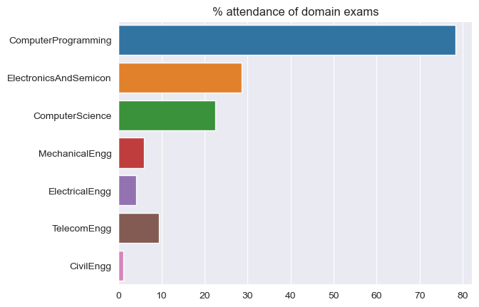

```python
plt.title('% attendance of domain exams')
sns.barplot(x=attendance,y=domains.columns)
```

#### Observation

- 78% of Candidates gave Computer Programming domain exam in Amcat

### Relationship between Salary and Logical,English,Quant Scores

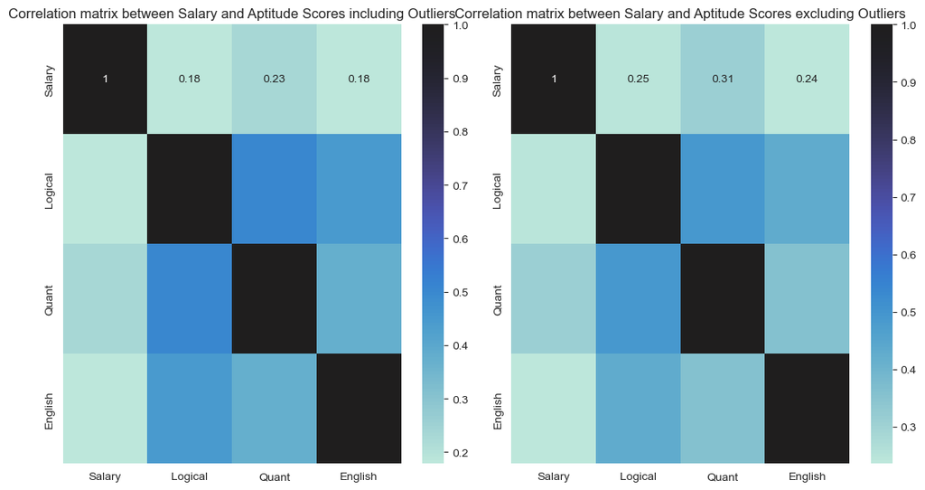

```python
plt.figure(figsize=(11,6))
plt.subplot(121)
plt.title('Correlation matrix between Salary and Aptitude Scores including Outliers')
sns.heatmap(df[['Salary','Logical','Quant','English']].corr(),annot=True,center=1)
plt.subplot(122)
plt.title('Correlation matrix between Salary and Aptitude Scores excluding Outliers')
sns.heatmap(clean_df[['Salary','Logical','Quant','English']].corr(),annot=True,center=1)
plt.tight_layout()
```

### Observation

- Quantitative Reasoning has highest correlaiton with the salary

### Relationship between Salary and Big 5 Personality Checks

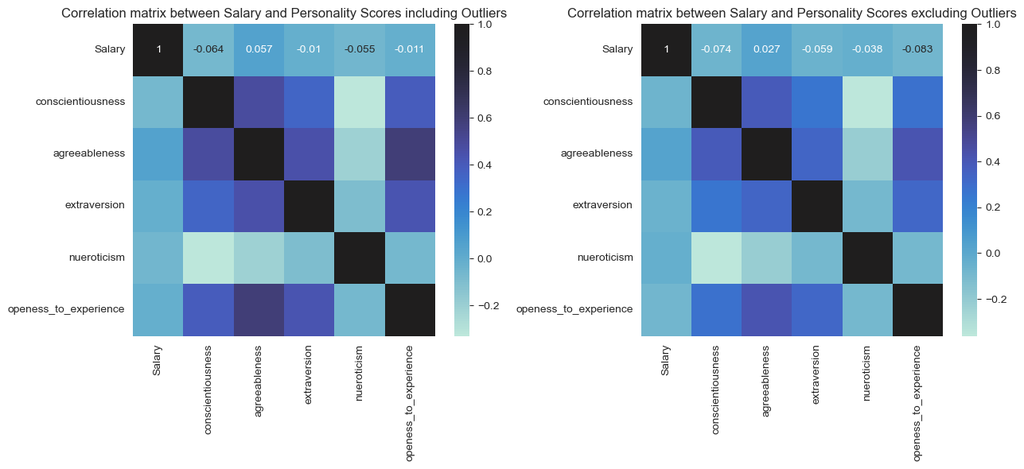

```python
plt.figure(figsize=(13,6))
plt.subplot(121)
plt.title('Correlation matrix between Salary and Personality Scores including Outliers')
sns.heatmap(df[['Salary','conscientiousness', 'agreeableness', 'extraversion', 'nueroticism','openess_to_experience']].corr(),annot=True,center=1)
plt.subplot(122)
plt.title('Correlation matrix between Salary and Personality Scores excluding Outliers')
sns.heatmap(clean_df[['Salary','conscientiousness', 'agreeableness', 'extraversion', 'nueroticism','openess_to_experience']].corr(),annot=True,center=1)
plt.tight_layout()
```

#### Observation

- Personality scores and Salary are not highly correlated

# Research Question

Times of India article dated Jan 18, 2019 states that “After doing your Computer Science Engineering if you take up jobs as a Programming Analyst, Software Engineer, Hardware Engineer and Associate Engineer you can earn up to 2.5-3 lakhs as a fresh graduate.”

H0- Mean salary is 2.75L

H1- Mean salary is not 2.75L

```python
# Consider all specializations which have computer word in it
computer_jobs=df[['Specialization','Designation','Salary']][df['Specialization'].str.contains('computer',regex=False)]
t_stats,p_val,result=[],[],[]
def t_test(designation):
    t_statistic, p_value =  stats.ttest_1samp(computer_jobs['Salary'][computer_jobs['Designation']==designation],2.75)

    print("T-statistic:", t_statistic)
    print("P-value:", p_value)
    t_stats.append(t_statistic)
    p_val.append(p_value)

    if t_statistic<0 or t_statistic==None:
        print('Not enough data')
    elif p_value<0.05 and t_statistic>0:
        print('Null Hypothesis is rejected---Mean Salary for {} is not equal to 2.75'.format(designation))
    else:
        print('Null Hypothesis is not rejected---Mean Salary for {} is  equal to 2.75'.format(designation))
```

```python
for designation in ['programmer analyst','software engineer','hardware engineer','associate engineer']:
    t_test(designation)
```

```
T-statistic: 9.662583462303736
P-value: 1.5624620958175607e-13
Null Hypothesis is rejected---Mean Salary for programmer analyst is not equal to 2.75
T-statistic: 7.816693023627976
P-value: 1.1365392982872651e-13
Null Hypothesis is rejected---Mean Salary for software engineer is not equal to 2.75
T-statistic: nan
P-value: nan
Null Hypothesis is not rejected---Mean Salary for hardware engineer is  equal to 2.75
T-statistic: -0.7019212139086011
P-value: 0.53328424401178
Not enough data
```

```python
result=['Null Hypothesis is rejected','Null Hypothesis is rejected','Not Enough Data','Not Enough Data']
result_df=pd.DataFrame(data={'Designation':['programmer analyst','software engineer','hardware engineer','associate engineer'],
                             'T-statistic':t_stats,'p-value':p_val,'Result':result})
result_df
```

[output not shown]

#### Observation

- For Programmer analyst and Software Engineer Specializations, the mean salary is not 2.75 Lakhs as mentioned in the news article
- For Hardware Engineer and Associate Engineer, there is not enough data to perform a accurate Hypothesis testing

## Specialization vs Gender

Is there a relationship between gender and specialization? (i.e. Does the preference of Specialisation depend on the Gender?)

Ho- Null Hypothesis: There does not exist a significant relationship

H1- Alternate Hypthesis: There does exist a significant relationship.

```python
from scipy.stats import chi2_contingency
contingency_table = pd.crosstab(df['Specialization'],df['Gender'])
chi2_stat, p_val, dof, expected = chi2_contingency(contingency_table)
# Print the results
print("Chi-square statistic:", chi2_stat)
print("P-value:", p_val)
print(p_val<0.05)
```

```
Chi-square statistic: 104.46891913608454
P-value: 1.2453868176977011e-06
True
```

| Chi2 statistic | 104.46891913608454 |
| --- | --- |
| p-value | 1.2453868176977011e-06 |
| result | Null Hypothesis is rejected |

As p-val is less than 0.05. We reject null hypothesis, thus there exist significant relation ship between specialization and gender